# Analisis de los datos de migraciones de la mosca de las frutas

Yhon Tiahuallpa

10/6/2020

## Paso 1: Abrir el archivo

Primero debemos leer los datos del archivo medfly.txt

```r
# <- se coloca con Alt + -

medfly <- read.table("./Semana 1-20200610/medfly.txt", header = TRUE, sep = '\t')
```

Vamos a mostrar las 10 primeras filas de la base de datos

```r
#Se puede colocar las lineas de codigo con Control + Alt + i

medfly[1:10, ]
```

```
##    trap        x        y south      alt dist loc_host    A  W
## 1    72 211353.7 632340.9     1 726.6240 29.5        1 2696 16
## 2    92 142408.4 535646.2     1 240.7184 30.0        1    7 18
## 3    97 142721.0 535212.8     1 240.4684 30.0        1  169 19
## 4   910 142770.8 535113.3     1 244.8809 30.0        0   32 19
## 5   911 142834.7 535013.8     1 246.4829 30.0        0    1  9
## 6   913 145416.6 536192.0     1 232.6738 29.0        0    0 NA
## 7   916 145820.5 535984.4     1 240.7439 29.0        0    0 NA
## 8   917 145947.4 535880.5     1 240.6470 29.0        0   13 20
## 9   925 145016.1 533052.7     1 229.9974  0.0        0  177 19
## 10  926 145087.1 532981.7     1 232.6426  0.0        1  935 18
```

Mostramos algunas de las variables: “trap” y “A”

```r
#Para mostrar los datos de la variable "trap"
medfly$trap
```

```
##  [1]   72   92   97  910  911  913  916  917  925  926  932  933  935  938  939
## [16] 1035 1200 1205 1220 1225 1240 1245 1260 1270 1271 1274 1280 1290 1291 1292
## [31] 1295 1305 1308 1310 1311 1315 1319 1320 1321 1322 1323 1325 1326 1327 1328
## [46] 1334 1337 1342 1344 1362 1383 1384 9103 9105 9106 9112 9115 9118 9119 9123
## [61] 9128 9129 9130 9131 9136 9139 9143 9144 9202 9203 9204 9205 9206 9210 9212
## [76] 9219 9221 9222 9225 9226 9232 9235 9252 9254 9256 9257 9259 9260 9262
```

```r
#Para mostrar los datos de la variable "A"
medfly$A
```

```
##  [1] 2696    7  169   32    1    0    0   13  177  935   33    7    8  769    0
## [16]  563 1081  611 2684   70  495  848   54  301  377    5  497  273   36   17
## [31]   82  812  368  996  251   20  203    6   23   35 1655 1051  142  190    4
## [46] 1849 2686 3055  276  616  756 2087   15   23   13 1228   97  205   86 1191
## [61]   29    2    8  120   45   37 1018  852    3   10  492  117  908   50   34
## [76]   42    0  994  155   80    9    1    8    0   25  221  176   60  343
```

## Paso 2: Análisis Preliminar

Es necesario hacer un analisis preliminar para encontrar errores en los datos, y además para saber qué tipo de modelo vamos a ajustar a los datos

#### Variable South

Para lo cual se mostrará un grafico: Histograma

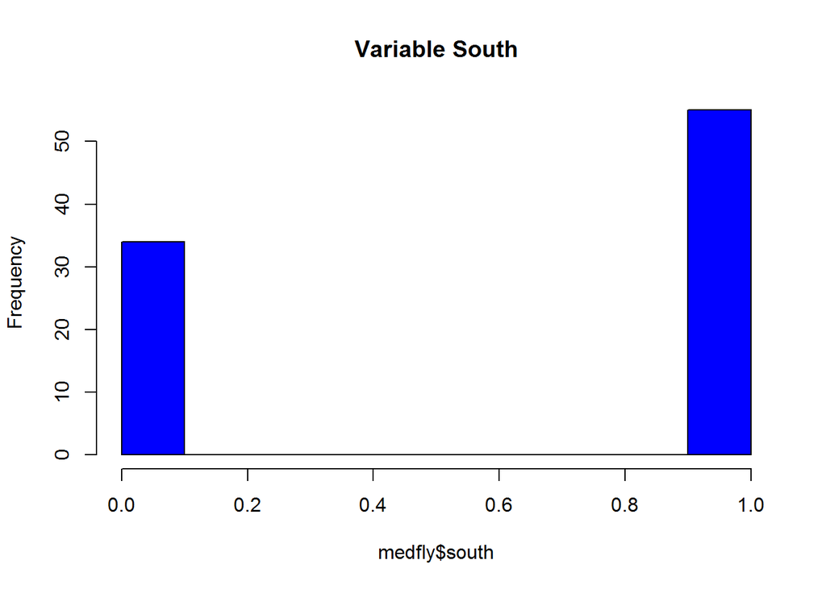

```r
hist(medfly$south, col = "blue", main = "Variable South")
```

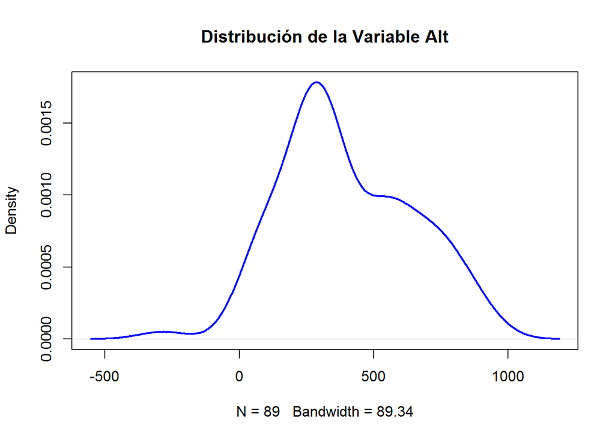

```r
plot(density(medfly$alt), col = "blue", lwd = 2, main = "Distribución de la Variable Alt")
```

```r
range(medfly$alt)
```

```
## [1] -284.5530  922.4256
```

#### Variable Alt

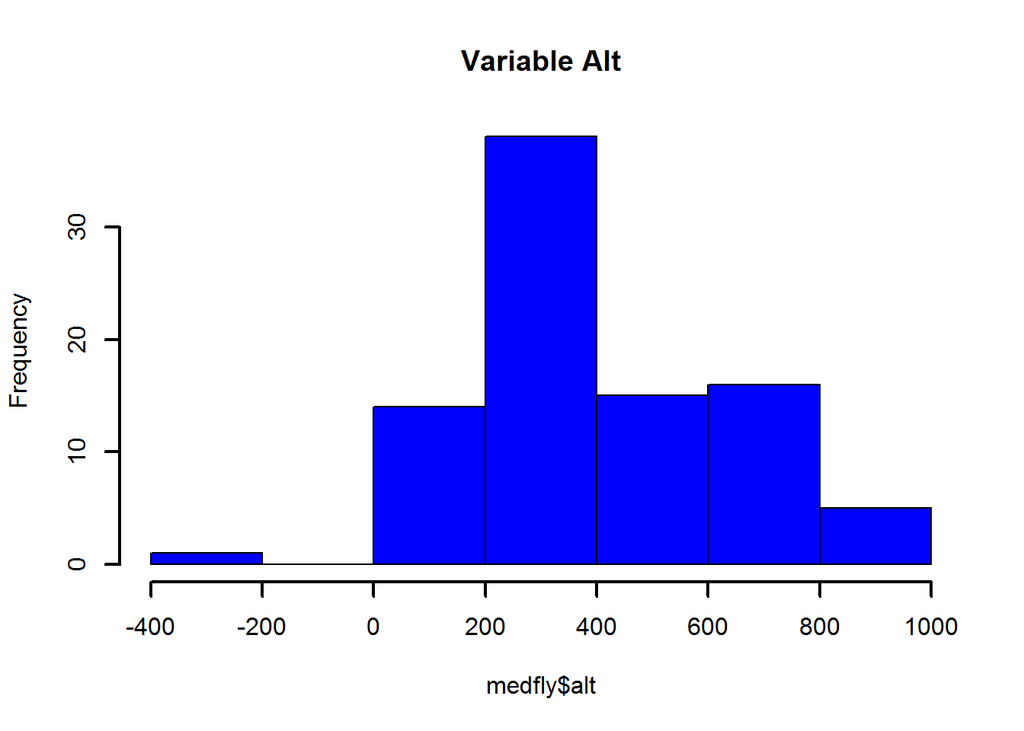

```r
hist(medfly$alt, col = "blue", lwd = 2, main = "Variable Alt")
```

Observen, que hay una observación con un valor negativo. Si es un error en los datos, esta observación no puede ser utilizada para ajustar un modelo!

En Israel existen lugares que estan debajo del nivel del mar, entonces no es error.

#### Variable dist

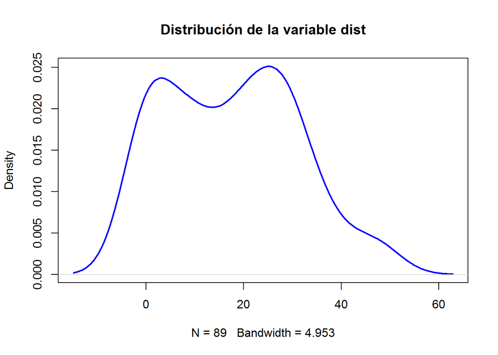

```r
plot(density(medfly$dist), col = "blue", lwd = 2, main = "Distribución de la variable dist")
```

```r
range(medfly$dist)
```

```
## [1]  0 48
```

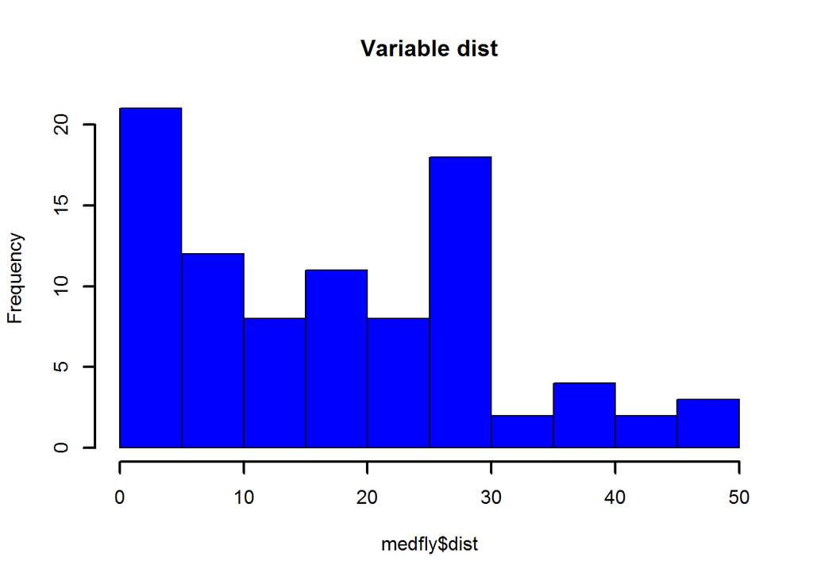

```r
hist(medfly$dist, col = "blue", lwd = 2, main = "Variable dist")
```

Hay pocas trampas que están a distancia de más de 30 km de las regiones calientes. Esta información puede ser útil cuando ajustamos el modelo o analizamos los resultados

#### Variable loc host

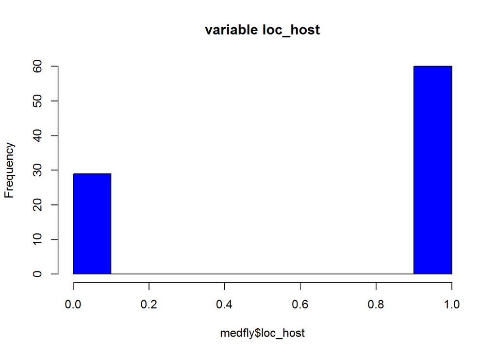

```r
hist(medfly$loc_host, col = "blue", main = "variable loc_host")
```

Esta variable binaria también puede ser utilizada cuando ajustamos un modelo puesto que hay suficientes observaciones con en cada categoría.

#### Variable A- la variable dependiente

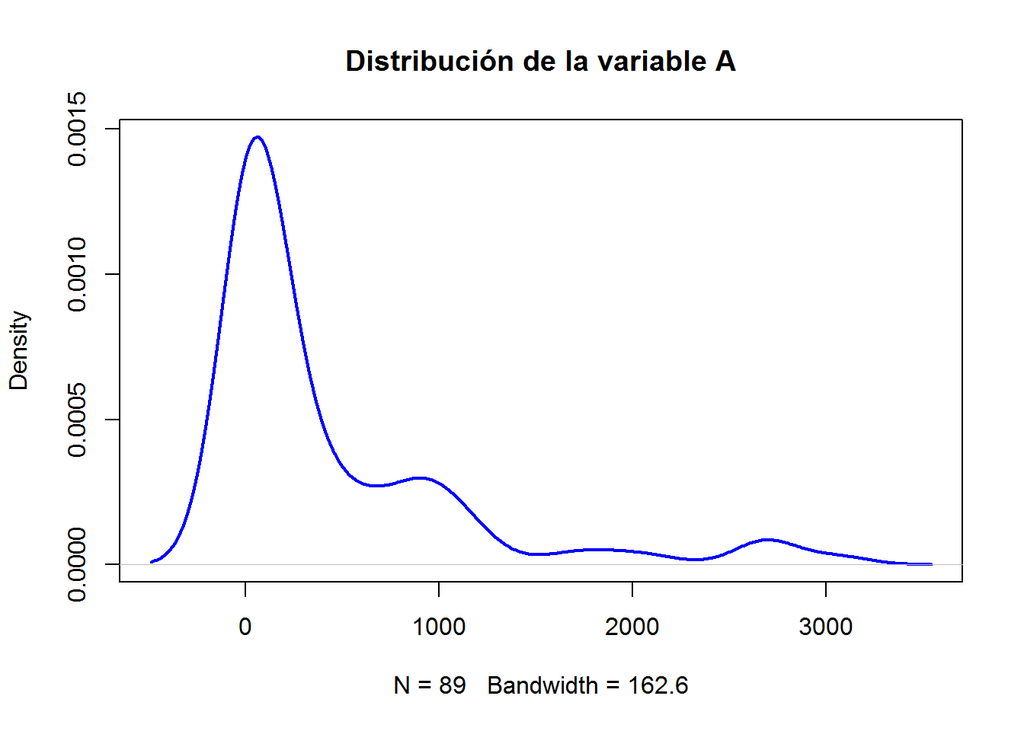

```r
plot(density(medfly$A), col = "blue", lwd = 2, main = "Distribución de la variable A")
```

```r
range(medfly$A)
```

```
## [1]    0 3055
```

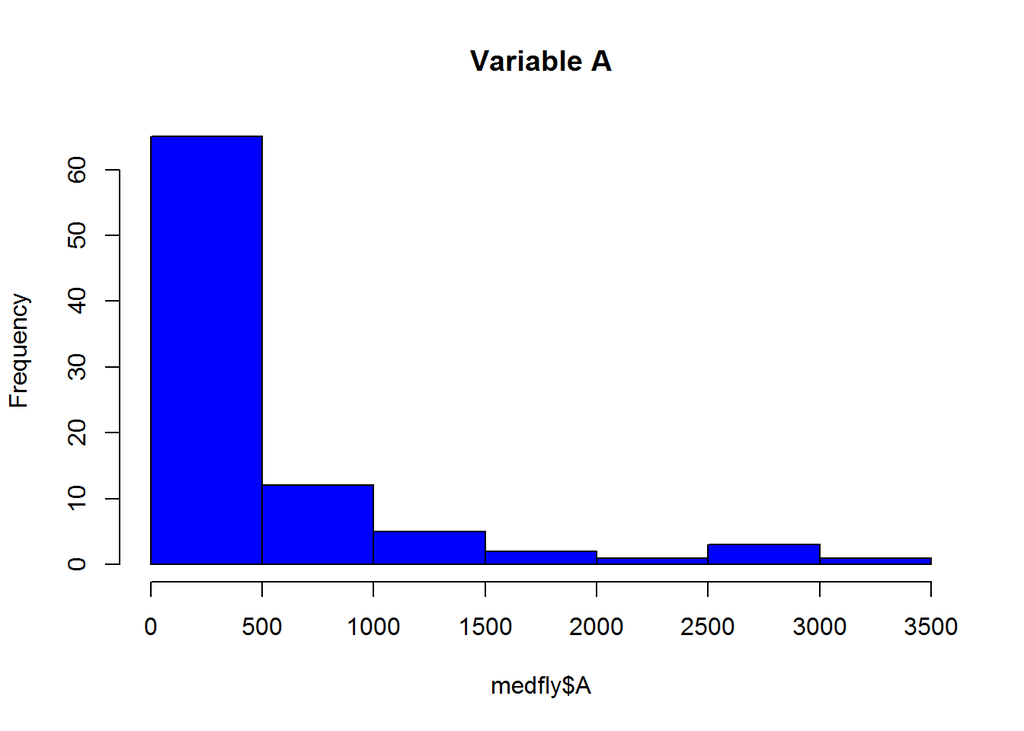

```r
hist(medfly$A, col = "blue", main = "Variable A")
```

Parece que aquí tenemos que hacer una transformación (porqué?)

Porque los datos no se distribucyen como una normal, por lo que se le realiza esa transformación a la variable.

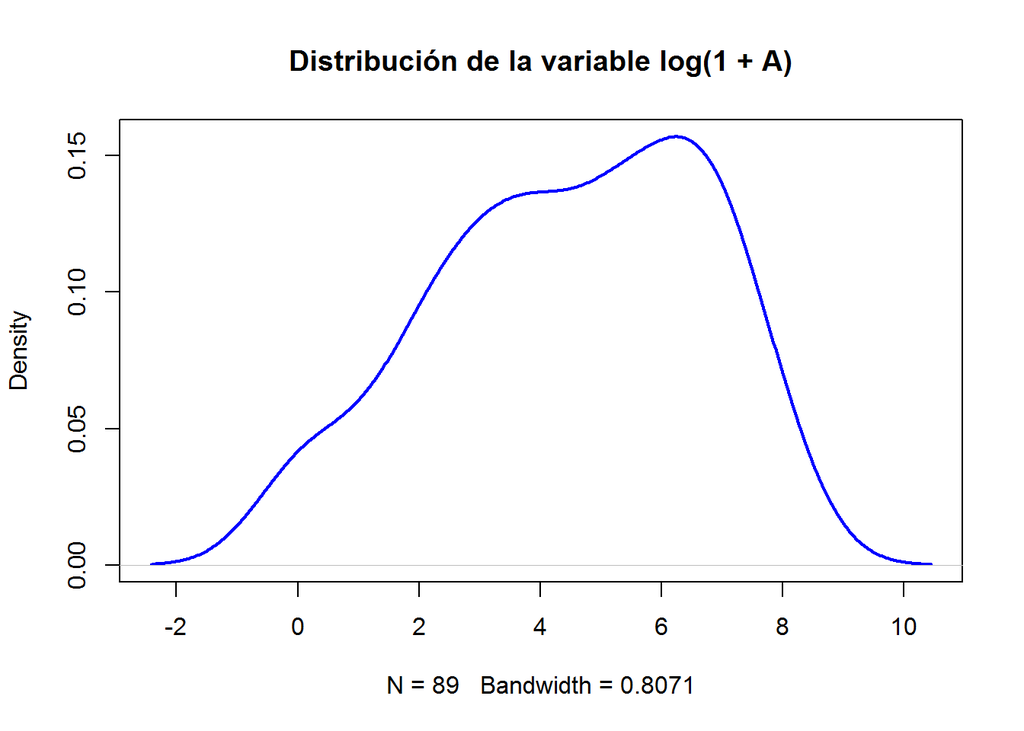

```r
plot(density(log(1 + medfly$A)), col = "blue", lwd = 2, main = "Distribución de la variable log(1 + A)")
```

```r
range((log(1+medfly$A)))
```

```
## [1] 0.000000 8.024862
```

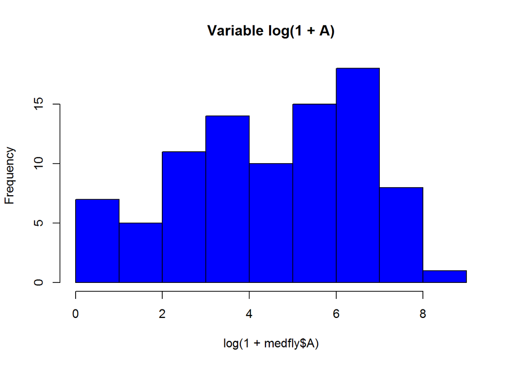

```r
hist(log(1 + medfly$A), col = "blue", main = "Variable log(1 + A)")
```

Entonces vamos a utilizar la variable log(1+A) como la variable dependiente. (Porqué no log(A)?)

Veamos:

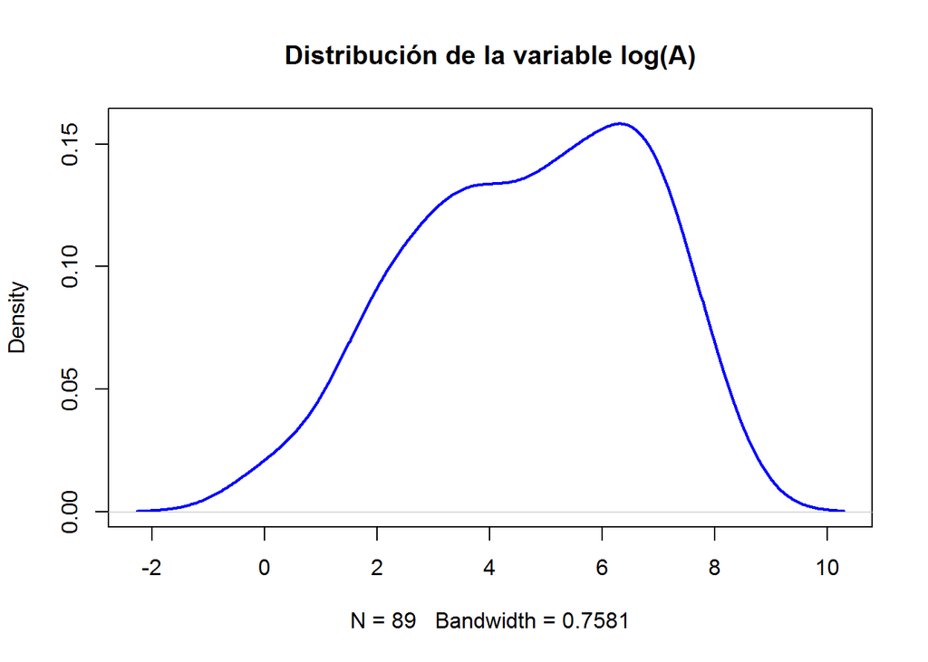

```r
plot(density(log(medfly$A)), col = "blue", lwd = 2, main = "Distribución de la variable log(A)")
```

```r
range((log(medfly$A)))
```

```
## [1]     -Inf 8.024535
```

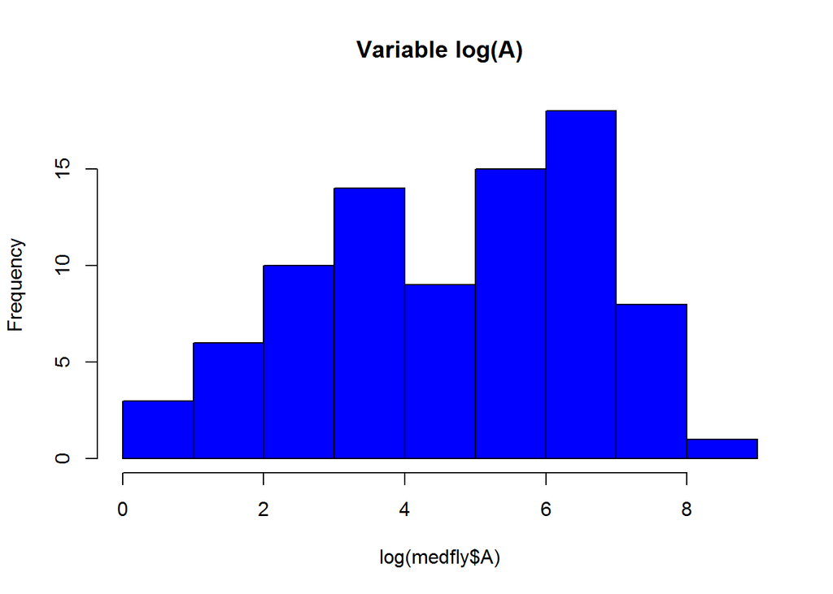

```r
hist(log(medfly$A), col = "blue", main = "Variable log(A)")
```

Creo que es por el rango que va desde -infinito

```r
medfly$W
```

```
##  [1] 16 18 19 19  9 NA NA 20 19 18 18 17 19 19 NA  8  1  2  9 16 12  9 11 15 14
## [26] 25 16 18 18 21 17 17 11  2  0 19 18 15 17 20 15 14  6 10 10 15 13  6  2 17
## [51]  6 10 17 17 18  6  1 18 19 17  1  3 21 19 17 18  1  0 26 21 17 18 18 25 19
## [76] 24 NA 18 19 19 10 21 20 NA 19 18 18 26 19
```